# Tarea 1: Análisis de Canastas

Alejandra Lelo de Larrea Ibarra

24/1/2019

# Librerías

```r
# Cargamos librerías
library(arules)
```

```r
library(arulesViz)
library(tidyverse)
library(tidygraph)
library(ggraph)
```

# Datos

Leemos los datos de **recetas** para poder hacer el análisis.

```r
# Leemos los datos de recetas.
datos<-read_csv('../datos/recetas/srep00196-s3.csv')
```

Regiones:

```r
# Extraemos las regiones existentes
unique(datos$region)
```

```
##  [1] "African"          "EastAsian"        "EasternEuropean"
##  [4] "LatinAmerican"    "MiddleEastern"    "NorthAmerican"
##  [7] "NorthernEuropean" "SouthAsian"       "SoutheastAsian"
## [10] "SouthernEuropean" "WesternEuropean"
```

```r
# Función para filtrar los datos por la región que quieras y generar el
# formato de transacciones
creaTransacciones<-function(Region='LatinAmerican',data=datos){

  # Filtramos los datos de la región deseada.
  recetas<-data%>%
    filter(region==Region)%>%
    select(-region)%>%
    apply(1,as.list)

  # Eliminar NA's
  recetas<-recetas %>%
    lapply(function(x){x[!(is.na(x))]})%>%
    lapply(unlist)
}

# Obtenemos los datos para latino-américa
recetasLA<-creaTransacciones()
```

# Análisis de Canastas frecuentes

Pedimos canastas frecuentes que aparezcan en al menos 10% de las recetas. Esto es, que aparezcan en al menos 291 recetas de las 2,917 disponibles.

```r
# Fijamos parámetros
pars<-list(supp=0.1, target='frequent itemsets')

# Algoritmo apriori para conjuntos frecuentes
ap<-apriori(recetasLA,parameter = pars)
```

```
## Apriori
##
## Parameter specification:
##  confidence minval smax arem  aval originalSupport maxtime support minlen
##          NA    0.1    1 none FALSE            TRUE       5     0.1      1
##  maxlen            target   ext
##      10 frequent itemsets FALSE
##
## Algorithmic control:
##  filter tree heap memopt load sort verbose
##     0.1 TRUE TRUE  FALSE TRUE    2    TRUE
##
## Absolute minimum support count: 291
##
## set item appearances ...[0 item(s)] done [0.00s].
## set transactions ...[260 item(s), 2917 transaction(s)] done [0.00s].
## sorting and recoding items ... [26 item(s)] done [0.00s].
## creating transaction tree ... done [0.00s].
## checking subsets of size 1 2 3 4 5 done [0.00s].
## writing ... [213 set(s)] done [0.00s].
## creating S4 object  ... done [0.00s].
```

```r
ap
```

```
## set of 213 itemsets
```

Se obtiene un total de 213 canastas frecuentes. Exploremos cada uno de los tamaños de los itemsets.

## Itemsets tamaño 1

```r
# Canastas frecuentes de tamaño 1
ap_1<-subset(ap,size(ap)==1)

length(ap_1)
```

```
## [1] 26
```

```r
# Revisamos las canastas
inspect(sort(ap_1, by='support'))
```

```
##      items               support   count
## [1]  {cayenne}           0.6671238 1946
## [2]  {onion}             0.6534110 1906
## [3]  {garlic}            0.6006171 1752
## [4]  {tomato}            0.5413096 1579
## [5]  {corn}              0.2975660  868
## [6]  {cumin}             0.2855674  833
## [7]  {vegetable_oil}     0.2509427  732
## [8]  {cilantro}          0.2482002  724
## [9]  {wheat}             0.2262599  660
## [10] {pepper}            0.2194035  640
## [11] {bell_pepper}       0.2070621  604
## [12] {black_pepper}      0.1974631  576
## [13] {olive_oil}         0.1906068  556
## [14] {cheese}            0.1861502  543
## [15] {oregano}           0.1813507  529
## [16] {cream}             0.1799794  525
## [17] {egg}               0.1779225  519
## [18] {cheddar_cheese}    0.1696949  495
## [19] {beef}              0.1628385  475
## [20] {chicken}           0.1439835  420
## [21] {butter}            0.1426123  416
## [22] {lime_juice}        0.1408982  411
## [23] {vinegar}           0.1360987  397
## [24] {scallion}          0.1319849  385
## [25] {milk}              0.1145012  334
## [26] {green_bell_pepper} 0.1145012  334
```

- Hay 26 canastas frecuentes de un sólo ingrediente. El top 10 de los ingredientes más frecuentes (individualmente) de la gastronomía latinoamericana son *cayenne*, *cebolla*, *ajo*, *tomate*, *maiz*, *comino*,*aceite vegetal*, *cilantro*, *trigo* y *pimienta*.
- Básicamente todos son sazonadores o especias salvo el maíz y el trigo que es la base de la tortilla, la masa y el pan. Nada sorprendente.
- El resto de los elementos en la lista son mas sazonadores y productos basicos.

## Itemsets tamaño 2

```r
# Canastas frecuentes de tamaño 1
ap_2<-subset(ap,size(ap)==2)

length(ap_2)
```

```
## [1] 71
```

Hay 71 itemsets frecuentes de dos ingredientes.

```r
# Revisamos las canastas
inspect(sort(ap_2, by='support'))
```

```
##      items                     support   count
## [1]  {cayenne,onion}           0.5128557 1496
## [2]  {garlic,onion}            0.4991430 1456
## [3]  {cayenne,garlic}          0.4844018 1413
## [4]  {onion,tomato}            0.4586904 1338
## [5]  {cayenne,tomato}          0.4381214 1278
## [6]  {garlic,tomato}           0.4220089 1231
## [7]  {cumin,garlic}            0.2451148  715
## [8]  {cayenne,cumin}           0.2430579  709
## [9]  {cumin,onion}             0.2358588  688
## [10] {cayenne,corn}            0.2324306  678
## [11] {corn,onion}              0.2159753  630
## [12] {corn,tomato}             0.2015770  588
## [13] {cayenne,cilantro}        0.1995201  582
## [14] {corn,garlic}             0.1991772  581
```

[output cut: 57 more lines]

- Los primeros 10 son parejas de sazonadores, especias y hierbas.
- Algunas parejas que me sorprendieron: (beef,tomato), (beef, onion), (garlic, wheat).

## Itemsets tamaño 3

```r
# Canastas frecuentes de tamaño 1
ap_3<-subset(ap,size(ap)==3)

length(ap_3)
```

```
## [1] 78
```

Hay 78 canastas frecuentes de 3 ingredientes.

```r
# Revisamos las canastas
inspect(sort(ap_3, by='support'))
```

```
##      items                           support   count
## [1]  {cayenne,garlic,onion}          0.4199520 1225
## [2]  {cayenne,onion,tomato}          0.3829277 1117
## [3]  {garlic,onion,tomato}           0.3784710 1104
## [4]  {cayenne,garlic,tomato}         0.3630442 1059
## [5]  {cumin,garlic,onion}            0.2156325  629
## [6]  {cayenne,cumin,garlic}          0.2152897  628
## [7]  {cayenne,cumin,onion}           0.2104902  614
## [8]  {cayenne,corn,onion}            0.1840932  537
## [9]  {corn,garlic,onion}             0.1765513  515
## [10] {cayenne,cumin,tomato}          0.1758656  513
## [11] {cumin,onion,tomato}            0.1758656  513
## [12] {cumin,garlic,tomato}           0.1755228  512
## [13] {cayenne,corn,garlic}           0.1724374  503
## [14] {cayenne,corn,tomato}           0.1693521  494
```

[output cut: 64 more lines]

- Siguen siendo combinaciones de sazonadores y especias
- Ninguna tercia pareciera dar indicios de un platillo en específico.

## Itemsets tamaño 4

```r
# Canastas frecuentes de tamaño 1
ap_4<-subset(ap,size(ap)==4)

length(ap_4)
```

```
## [1] 34
```

Hay 34 itemsets frecuentes de 4 ingredientes.

```r
# Revisamos las canastas
inspect(sort(ap_4, by='support'))
```

```
##      items                                 support   count
## [1]  {cayenne,garlic,onion,tomato}         0.3345903 976
## [2]  {cayenne,cumin,garlic,onion}          0.1960919 572
## [3]  {cumin,garlic,onion,tomato}           0.1642098 479
## [4]  {cayenne,cumin,onion,tomato}          0.1631814 476
## [5]  {cayenne,cumin,garlic,tomato}         0.1624957 474
## [6]  {cayenne,corn,garlic,onion}           0.1580391 461
## [7]  {corn,garlic,onion,tomato}            0.1467261 428
## [8]  {cayenne,corn,onion,tomato}           0.1463833 427
## [9]  {cayenne,corn,garlic,tomato}          0.1443264 421
## [10] {cayenne,garlic,onion,oregano}        0.1343846 392
## [11] {black_pepper,cayenne,garlic,onion}   0.1278711 373
## [12] {cayenne,garlic,onion,vegetable_oil}  0.1227288 358
## [13] {cayenne,cilantro,garlic,onion}       0.1182722 345
## [14] {bell_pepper,cayenne,garlic,onion}    0.1162153 339
```

[output cut: 20 more lines]

- Todos son combinaciones de sazonadores, especias y hierbas.
- Ya no aparece ninguna proteina.
- Son la base para preparar cualquier platillo.

## Itemsets tamaño 5

```r
# Canastas frecuentes de tamaño 1
ap_5<-subset(ap,size(ap)==5)

length(ap_5)
```

```
## [1] 4
```

Sólo hay 4 itemsets frecuentes de 5 ingredientes.

```r
# Revisamos las canastas
inspect(sort(ap_5, by='support'))
```

```
##     items                                       support   count
## [1] {cayenne,cumin,garlic,onion,tomato}         0.1542681 450
## [2] {cayenne,corn,garlic,onion,tomato}          0.1336990 390
## [3] {cayenne,cumin,garlic,onion,oregano}        0.1059308 309
## [4] {cayenne,garlic,onion,tomato,vegetable_oil} 0.1001028 292
```

- Siguen siendo combinaciones de sazonadores especias y hiervas.

## Itemsets específicos

Vamos a buscar algunas proteinas

```r
ap_beef<-subset(ap,items %pin% 'beef')
length(ap_beef)
```

```
## [1] 9
```

```r
inspect(sort(ap_beef,by='support'))
```

```
##     items                 support   count
## [1] {beef}                0.1628385 475
## [2] {beef,onion}          0.1398697 408
## [3] {beef,tomato}         0.1258142 367
## [4] {beef,cayenne}        0.1203291 351
## [5] {beef,garlic}         0.1196435 349
## [6] {beef,onion,tomato}   0.1155297 337
## [7] {beef,cayenne,onion}  0.1076448 314
## [8] {beef,garlic,onion}   0.1069592 312
## [9] {beef,cayenne,tomato} 0.1004457 293
```

```r
ap_chicken<-subset(ap,items %pin% 'chicken')
length(ap_chicken)
```

```
## [1] 4
```

```r
inspect(sort(ap_chicken,by='support'))
```

```
##     items             support   count
## [1] {chicken}         0.1439835 420
## [2] {cayenne,chicken} 0.1141584 333
## [3] {chicken,onion}   0.1138156 332
## [4] {chicken,garlic}  0.1062736 310
```

```r
ap_corn<-subset(ap,items %pin% 'corn')
length(ap_corn)
```

```
## [1] 16
```

```r
inspect(sort(ap_corn,by='support'))
```

```
##      items                              support   count
## [1]  {corn}                             0.2975660 868
## [2]  {cayenne,corn}                     0.2324306 678
## [3]  {corn,onion}                       0.2159753 630
## [4]  {corn,tomato}                      0.2015770 588
## [5]  {corn,garlic}                      0.1991772 581
## [6]  {cayenne,corn,onion}               0.1840932 537
## [7]  {corn,garlic,onion}                0.1765513 515
## [8]  {cayenne,corn,garlic}              0.1724374 503
## [9]  {cayenne,corn,tomato}              0.1693521 494
## [10] {corn,onion,tomato}                0.1672952 488
## [11] {corn,garlic,tomato}               0.1635242 477
## [12] {cayenne,corn,garlic,onion}        0.1580391 461
## [13] {corn,garlic,onion,tomato}         0.1467261 428
## [14] {cayenne,corn,onion,tomato}        0.1463833 427
## [15] {cayenne,corn,garlic,tomato}       0.1443264 421
## [16] {cayenne,corn,garlic,onion,tomato} 0.1336990 390
```

- Hay 16 itemsets frecuentes que contiene maíz.
- Aproximadamente el 29% de las recetas llevan maíz.
- Se cocina en su mayoría con especias o hierbas, pero no con proteína. ¿tortillas? ¿pan?

## Modelo de Ingredientes Independientes

Veamos si los ingredientes de la cocina latinoamericana se pueden considerar como independientes. Para ello se hacen simulaciones utilzando los datos observados.

```r
# Función para simular recetas
simular_recetas <- function(nItems, nRecetas, iprob){

  # Etiquetas para los n artículos
  etiquetas <- 1:nItems
  if(!is.null(names(iprob))) {

    # cambia etiquetas a nombre del articulo
    etiquetas <- names(iprob)
  }
  # Genera nRecetas recetas simulando binomiales de tamaño 1 para el
  # no. de ingredientes observado con las prob observadas en los datos.
  recetas <- lapply(1:nRecetas, function(i){
      etiquetas[which(rbinom(nItems, 1, prob = iprob) == 1)]
  })
  # Devolver la canasta
  recetas
}
```

Simulamos 10,000 recetas de los 260 ingredientes disponibles en la cultura latinoamericana con las frecuencias observadas en los datos.

```r
# Fijamos la semilla
set.seed(25021987)

# Convertimos la canasta a tipo transactions
recetasLA_trans<-as(recetasLA,"transactions")

# Obtenemos los soportes (itemFrequency) para los artículos y los ordenamos
probs_ingredients <- sort(itemFrequency(recetasLA_trans))

# Simulamos 10000 recetas Se tienen 260 ingredientes en los datos
# con probabilidades dadas por el soporte de cada uno.
recetas_sims <- simular_recetas(nItems = 260, nRecetas = 10000,
                               iprob = probs_ingredients)

# Calculamos las canastas frecuentes para soporte 0.005
# con algoritmo apriori.
ap_indep <- apriori(recetas_sims,
                    parameter = list(support=0.1, target='frequent itemsets'),
                       control = list(verbose = FALSE))
ap_indep
```

```
## set of 107 itemsets
```

- Se tienen 107 itemsets frecuentes en el modelo de ingredientes idependientes.

### Itemsets tamaño 1

```r
# Itemsets de tamaño 1
# Canastas frecuentes de tamaño 1
ap_indep_1<-subset(ap_indep,support>0.1 & size(ap_indep)==1)

length(ap_indep_1) # aquí 213, antes
```

```
## [1] 27
```

```r
# Revisamos las canastas
inspect(sort(ap_indep_1, by='support'))
```

```
##      items               support count
## [1]  {cayenne}           0.6699  6699
## [2]  {onion}             0.6570  6570
## [3]  {garlic}            0.6006  6006
## [4]  {tomato}            0.5438  5438
## [5]  {corn}              0.3070  3070
## [6]  {cumin}             0.2744  2744
## [7]  {vegetable_oil}     0.2529  2529
## [8]  {cilantro}          0.2462  2462
## [9]  {wheat}             0.2226  2226
## [10] {pepper}            0.2180  2180
## [11] {bell_pepper}       0.2081  2081
## [12] {black_pepper}      0.1949  1949
## [13] {cheese}            0.1932  1932
## [14] {oregano}           0.1868  1868
## [15] {olive_oil}         0.1832  1832
## [16] {egg}               0.1800  1800
## [17] {cheddar_cheese}    0.1746  1746
## [18] {cream}             0.1745  1745
## [19] {beef}              0.1622  1622
## [20] {chicken}           0.1464  1464
## [21] {lime_juice}        0.1404  1404
## [22] {butter}            0.1384  1384
## [23] {vinegar}           0.1363  1363
## [24] {scallion}          0.1301  1301
## [25] {milk}              0.1173  1173
## [26] {green_bell_pepper} 0.1134  1134
## [27] {avocado}           0.1020  1020
```

- Se tienen 27 itemsets frecuentes de 1 ingrediente
- Prácticamente igual que en los datos observados. En el top 10, sólo sazonadores, especias y hierbas más el trigo y el maíz.

### Itemsets tamaño 2

```r
# Itemsets de tamaño 2
# Canastas frecuentes de tamaño 2
ap_indep_2<-subset(ap_indep,support>0.1 & size(ap_indep)==2)

length(ap_indep_2) # aquí 213, antes
```

```
## [1] 62
```

```r
# Revisamos las canastas
inspect(sort(ap_indep_2, by='support'))
```

```
##      items                    support count
## [1]  {cayenne,onion}          0.4419  4419
## [2]  {cayenne,garlic}         0.4042  4042
## [3]  {garlic,onion}           0.3956  3956
## [4]  {cayenne,tomato}         0.3629  3629
## [5]  {onion,tomato}           0.3582  3582
## [6]  {garlic,tomato}          0.3256  3256
## [7]  {cayenne,corn}           0.2054  2054
## [8]  {corn,onion}             0.2011  2011
## [9]  {corn,garlic}            0.1817  1817
## [10] {cayenne,cumin}          0.1806  1806
## [11] {cumin,onion}            0.1789  1789
## [12] {cayenne,vegetable_oil}  0.1707  1707
## [13] {corn,tomato}            0.1698  1698
## [14] {cumin,garlic}           0.1673  1673
```

[output cut: 48 more lines]

- Se tienen 62 itemsets frecuentes de 2 ingreidentes.
- Combinación de sazonadores y hierbas en los 10 primeros.
- Similar a los datos observados.

### Itemsets tamaño 3

```r
# Itemsets de tamaño 3
ap_indep_3<-subset(ap_indep,support>0.1 & size(ap_indep)==3)

length(ap_indep_3)
```

```
## [1] 17
```

```r
# Revisamos las canastas
inspect(sort(ap_indep_3, by='support'))
```

```
##      items                          support count
## [1]  {cayenne,garlic,onion}         0.2673  2673
## [2]  {cayenne,onion,tomato}         0.2382  2382
## [3]  {cayenne,garlic,tomato}        0.2176  2176
## [4]  {garlic,onion,tomato}          0.2164  2164
## [5]  {cayenne,corn,onion}           0.1367  1367
## [6]  {cayenne,corn,garlic}          0.1214  1214
## [7]  {corn,garlic,onion}            0.1204  1204
## [8]  {cayenne,cumin,onion}          0.1194  1194
## [9]  {cayenne,onion,vegetable_oil}  0.1122  1122
## [10] {corn,onion,tomato}            0.1122  1122
## [11] {cayenne,cumin,garlic}         0.1119  1119
## [12] {cayenne,corn,tomato}          0.1118  1118
## [13] {cumin,garlic,onion}           0.1097  1097
## [14] {cayenne,cilantro,onion}       0.1089  1089
## [15] {cayenne,garlic,vegetable_oil} 0.1020  1020
## [16] {cayenne,cilantro,garlic}      0.1012  1012
## [17] {cayenne,onion,wheat}          0.1010  1010
```

- Se tienen sólo 17 itemsets frecuentes de tamaño 3. Mucho menos que en los datos observados.
- Combinaciones de sazonadores, hierbas y especias.
- No aparece ninguna proteína a diferencia de los datos observados.

### Itemsets tamaño 4

```r
# Itemsets de tamaño 4
ap_indep_4<-subset(ap_indep,support>0.1 & size(ap_indep)==4)

length(ap_indep_4)
```

```
## [1] 1
```

```r
# Revisamos las canastas
inspect(sort(ap_indep_4, by='support'))
```

```
##     items                         support count
## [1] {cayenne,garlic,onion,tomato} 0.1442  1442
```

- Sólo hay un itemset frecuente de 4 ingrdientes. Mucho menor a lo observado en los datos.
- Combinación de los 4 itemsets más frecuentes de tamaño 1.

## Comparativo Modelo Independiente vs Datos observados.

Hacemos 10 veces la simulación para garantizar que no fue “mala suerte” y verificar si los datos de recetas pueden considerase como ingredientes independientes para la comida en Latinoamérica.

```r
sims <- lapply(1:10, function(i){
  # Simula 10,000 canastas para los 169 artículos con las
  # probabilidades observadas en la muestra.
  recetas <- simular_recetas(nItems = 260,
                               nRecetas = 10000,
                               iprob = probs_ingredients)

  # Obtiene canastas frecuentes con algoritmo apriori y soporte>0.005.
  ap_indep <- apriori(recetas,
                      parameter = list(support=0.1, target='frequent itemsets'),
                       control = list(verbose = FALSE))

  # size devuelve un vector con el tamaño (no de artículos) de cada
  # itemset frecuente
  # con table se saca una tabla de frecuencias.
  df <- data.frame(table(size(ap_indep)))

  # No de modelo simulado
  df$rep <- i
  df
})
```

Obtenemos la tabla de frecuencias para los datos simulados.

```r
# Convierte cada elemento la lista en un solo data frame
df_sims <- bind_rows(sims)
```

Obtenemos la tabla de frecuencias para los datos observados.

```r
# Data frame para itemsets frecuentes observados
df_obs <- data.frame(table(size(ap)))
```

Graficamos el no. de itemsets frecuentes encontrados en los datos simulados y en los observados.

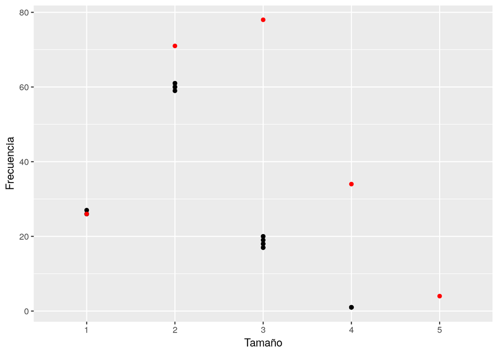

```r
# Grafica frecuencias en las simulaciones vs los datos observados
# por tamaño de itemset frecuente.
ggplot(df_sims, aes(x=Var1, y=Freq)) +
  geom_point() +
  geom_point(data = df_obs, colour = 'red') +
  labs(x = 'Tamaño',y='Frecuencia')
```

- Ajuste bueno para los itemsets de tamaño 1 y 2.
- Ajsute pésimo para itemsets de tamaño 3 y 4.
- No hay itemsets de tamaño 5 en los datos simulados.

Por lo tanto, los ingredientes no parecen tener un comportamiento de independencia. Veamos si hay evidencia de asociaciones positivas.

```r
# Buscamos los casos en que coinciden.
coinciden <- match(ap, ap_indep)

# No de coincidencias -> 101
sum(!is.na(coinciden))
```

```
## [1] 101
```

```r
# no de itemsets frecuentes observados -> 213
length(ap)
```

```
## [1] 213
```

```r
# no de itemsets frecuentes independientes -> 107
length(ap_indep)
```

```
## [1] 107
```

La mayoría de los itemsets frecuentes de los datos en el modelo independiente están en los itemsets frecuentes de los datos observados; sin embargo hhay aproximadamente un 50% de itemsets en los datos observados que no hacen match en los datos simulados del modelo independiente. Por lo tanto hay asociación positiva entre algunos de los ingredientes.

# Reglas de Asociación

## Usando sólo confianza.

### Soporte 10% y confianza mayor o igual a 5%.

```r
# Se definen parámetros
pars <- list(supp = 0.1, confidence = 0.05, target='rules',
             ext = TRUE, minlen = 2)
# Se corre el algoritmo apriori con soporte 0.01 y confianza 0.20
reglas <- apriori(recetasLA, parameter = pars)
```

```
## Apriori
##
## Parameter specification:
##  confidence minval smax arem  aval originalSupport maxtime support minlen
##        0.05    0.1    1 none FALSE            TRUE       5     0.1      2
##  maxlen target  ext
##      10  rules TRUE
##
## Algorithmic control:
##  filter tree heap memopt load sort verbose
##     0.1 TRUE TRUE  FALSE TRUE    2    TRUE
##
## Absolute minimum support count: 291
##
## set item appearances ...[0 item(s)] done [0.00s].
## set transactions ...[260 item(s), 2917 transaction(s)] done [0.00s].
## sorting and recoding items ... [26 item(s)] done [0.00s].
## creating transaction tree ... done [0.00s].
## checking subsets of size 1 2 3 4 5 done [0.00s].
## writing ... [532 rule(s)] done [0.00s].
## creating S4 object  ... done [0.00s].
```

```r
# no. reglas
length(reglas)
```

```
## [1] 532
```

Se encontraron 532 reglas para un soporte del 10% y con confianza del 5% .

```r
# Examinamos las primeras 10 reglas
inspect(sort(reglas, by='confidence')[1:100])
```

```
##       lhs                                      rhs       support
## [1]   {black_pepper,oregano}                => {garlic}  0.1021598
## [2]   {cayenne,cumin,onion,oregano}         => {garlic}  0.1059308
## [3]   {cumin,onion,oregano}                 => {garlic}  0.1107302
## [4]   {black_pepper,cumin,onion}            => {garlic}  0.1018169
## [5]   {cayenne,cumin,oregano}               => {garlic}  0.1114158
## [6]   {cumin,oregano}                       => {garlic}  0.1186150
## [7]   {black_pepper,cayenne,tomato}         => {onion}   0.1011313
## [8]   {cumin,garlic,onion,oregano}          => {cayenne} 0.1059308
## [9]   {cumin,onion,oregano}                 => {cayenne} 0.1083305
## [10]  {bell_pepper,garlic,tomato}           => {onion}   0.1045595
## [11]  {garlic,oregano,tomato}               => {onion}   0.1038738
## [12]  {onion,oregano,tomato}                => {garlic}  0.1038738
## [13]  {cayenne,onion,oregano}               => {garlic}  0.1343846
## [14]  {cayenne,cumin,garlic,oregano}        => {onion}   0.1059308
```

[output cut: 187 more lines]

Por ejemplo, el 10.21% tienen black pepper, oregano y garlic; el 10.42% de las recetas tiene black pepper y oregano; 98% de las recetas que tienen balck pepper y oregano también tienen garlic.

### Soporte 1% y confianza mayor o igual a 5%.

```r
# Se definen parámetros
pars <- list(supp = 0.01, confidence = 0.05, target='rules',
             ext = TRUE, minlen = 2)
# Se corre el algoritmo apriori con soporte 0.01 y confianza 0.20
reglas <- apriori(recetasLA, parameter = pars)
```

```
## Apriori
##
## Parameter specification:
##  confidence minval smax arem  aval originalSupport maxtime support minlen
##        0.05    0.1    1 none FALSE            TRUE       5    0.01      2
##  maxlen target  ext
##      10  rules TRUE
##
## Algorithmic control:
##  filter tree heap memopt load sort verbose
##     0.1 TRUE TRUE  FALSE TRUE    2    TRUE
##
## Absolute minimum support count: 29
##
## set item appearances ...[0 item(s)] done [0.00s].
## set transactions ...[260 item(s), 2917 transaction(s)] done [0.00s].
## sorting and recoding items ... [101 item(s)] done [0.00s].
## creating transaction tree ... done [0.00s].
## checking subsets of size 1 2 3 4 5 6 7 8 9 10
```

```
##  done [0.02s].
## writing ... [59339 rule(s)] done [0.01s].
## creating S4 object  ... done [0.01s].
```

```r
# no. reglas
length(reglas)
```

```
## [1] 59339
```

```r
# Examinamos las primeras 10 reglas
inspect(sort(reglas, by='confidence')[1:100])
```

```
##       lhs                                        rhs
## [1]   {milk_fat}                              => {milk}
## [2]   {celery_oil}                            => {vinegar}
## [3]   {celery_oil}                            => {corn}
## [4]   {celery_oil}                            => {tomato}
## [5]   {celery_oil}                            => {garlic}
## [6]   {yeast}                                 => {wheat}
## [7]   {buttermilk,garlic}                     => {egg}
## [8]   {buttermilk,onion}                      => {egg}
## [9]   {celery_oil,vinegar}                    => {corn}
## [10]  {celery_oil,corn}                       => {vinegar}
## [11]  {celery_oil,vinegar}                    => {tomato}
## [12]  {celery_oil,tomato}                     => {vinegar}
## [13]  {celery_oil,vinegar}                    => {garlic}
## [14]  {celery_oil,garlic}                     => {vinegar}
```

[output cut: 187 more lines]

```r
# Se definen parámetros
pars <- list(supp = 0.2, confidence = 0.5, target='rules',
             ext = TRUE, minlen = 2)
# Se corre el algoritmo apriori con soporte 0.01 y confianza 0.20
reglas <- apriori(recetasLA, parameter = pars)
```

```
## Apriori
##
## Parameter specification:
##  confidence minval smax arem  aval originalSupport maxtime support minlen
##         0.5    0.1    1 none FALSE            TRUE       5     0.2      2
##  maxlen target  ext
##      10  rules TRUE
##
## Algorithmic control:
##  filter tree heap memopt load sort verbose
##     0.1 TRUE TRUE  FALSE TRUE    2    TRUE
##
## Absolute minimum support count: 583
##
## set item appearances ...[0 item(s)] done [0.00s].
## set transactions ...[260 item(s), 2917 transaction(s)] done [0.00s].
## sorting and recoding items ... [11 item(s)] done [0.00s].
## creating transaction tree ... done [0.00s].
## checking subsets of size 1 2 3 4 done [0.00s].
## writing ... [40 rule(s)] done [0.00s].
## creating S4 object  ... done [0.00s].
```

```r
# no. reglas
length(reglas)
```

```
## [1] 40
```

```r
# Examinamos las primeras 10 reglas
inspect(sort(reglas, by='confidence'))
```

```
##      lhs                        rhs       support   confidence lhs.support
## [1]  {cayenne,garlic,tomato} => {onion}   0.3345903 0.9216242  0.3630442
## [2]  {cumin,onion}           => {garlic}  0.2156325 0.9142442  0.2358588
## [3]  {garlic,tomato}         => {onion}   0.3784710 0.8968318  0.4220089
## [4]  {cumin,onion}           => {cayenne} 0.2104902 0.8924419  0.2358588
## [5]  {cayenne,cumin}         => {garlic}  0.2152897 0.8857546  0.2430579
## [6]  {garlic,onion,tomato}   => {cayenne} 0.3345903 0.8840580  0.3784710
## [7]  {cumin,garlic}          => {onion}   0.2156325 0.8797203  0.2451148
## [8]  {cumin,garlic}          => {cayenne} 0.2152897 0.8783217  0.2451148
## [9]  {cayenne,tomato}        => {onion}   0.3829277 0.8740219  0.4381214
## [10] {cayenne,onion,tomato}  => {garlic}  0.3345903 0.8737690  0.3829277
## [11] {cayenne,garlic}        => {onion}   0.4199520 0.8669498  0.4844018
## [12] {cayenne,cumin}         => {onion}   0.2104902 0.8660085  0.2430579
## [13] {garlic,tomato}         => {cayenne} 0.3630442 0.8602762  0.4220089
## [14] {cumin}                 => {garlic}  0.2451148 0.8583433  0.2855674
```

[output cut: 67 more lines]

- Por ejemplo, el 33.4% tienen cayena, ajo, tomate y cebolla; el 36% tienen cayena, ajo y tomate; el 92% de las recetas que tieenen cayena, ajo y tomate también tienen cebolla.

### Observaciones

- Aumentar soporte (confianza fijo) disminuye no. de itemsets frecuentes. Disminuir soporte (confianza fijo) aumenta el no. de itemsets frecuentes.

## Usando lift (sorporte y confianza bajos)

```r
# Se definen parámetros
pars <- list(supp = 0.01, confidence = 0.1, target='rules',
             ext = TRUE, minlen = 2)
# Se corre el algoritmo apriori con soporte 0.01 y confianza 0.20
reglas <- apriori(recetasLA, parameter = pars)
```

```
## Apriori
##
## Parameter specification:
##  confidence minval smax arem  aval originalSupport maxtime support minlen
##         0.1    0.1    1 none FALSE            TRUE       5    0.01      2
##  maxlen target  ext
##      10  rules TRUE
##
## Algorithmic control:
##  filter tree heap memopt load sort verbose
##     0.1 TRUE TRUE  FALSE TRUE    2    TRUE
##
## Absolute minimum support count: 29
##
## set item appearances ...[0 item(s)] done [0.00s].
## set transactions ...[260 item(s), 2917 transaction(s)] done [0.00s].
## sorting and recoding items ... [101 item(s)] done [0.00s].
## creating transaction tree ... done [0.00s].
## checking subsets of size 1 2 3 4 5 6 7 8 9 10
```

```
##  done [0.02s].
## writing ... [58292 rule(s)] done [0.01s].
## creating S4 object  ... done [0.01s].
```

```r
# no. reglas
length(reglas)
```

```
## [1] 58292
```

```r
# Examinamos las primeras 10 reglas
inspect(sort(reglas, by='lift')[1:100])
```

```
##       lhs                 rhs                support confidence lhs.support     lift count
## [1]   {corn,
##        garlic,
##        tomato,
##        vinegar}        => {celery_oil}    0.01371272  0.5063291  0.02708262 36.92405    40
## [2]   {corn,
##        garlic,
##        onion,
##        tomato,
##        vinegar}        => {celery_oil}    0.01062736  0.4626866  0.02296880 33.74142    31
## [3]   {cane_molasses,
##        onion,
##        vinegar}        => {tamarind}      0.02331162  0.8192771  0.02845389 31.86442    68
## [4]   {corn,
##        garlic,
##        vinegar}        => {celery_oil}    0.01371272  0.4301075  0.03188207 31.36559    40
## [5]   {cane_molasses,
##        onion,
##        tomato,
##        vinegar}        => {tamarind}      0.01199863  0.7777778  0.01542681 30.25037    35
## [6]   {cane_molasses,
##        vinegar}        => {tamarind}      0.02331162  0.7727273  0.03016798 30.05394    68
## [7]   {cane_molasses,
##        garlic,
##        onion,
##        vinegar}        => {tamarind}      0.01371272  0.7692308  0.01782653 29.91795    40
## [8]   {corn,
##        tomato,
##        vinegar}        => {celery_oil}    0.01371272  0.4081633  0.03359616 29.76531    40
## [9]   {cane_molasses,
##        tomato,
##        vinegar}        => {tamarind}      0.01199863  0.7608696  0.01576963 29.59275    35
## [10]  {cane_molasses,
##        cayenne,
##        onion,
##        vinegar}        => {tamarind}      0.01199863  0.7608696  0.01576963 29.59275    35
## [11]  {corn,
##        onion,
##        tomato,
##        vinegar}        => {celery_oil}    0.01062736  0.3924051  0.02708262 28.61614    31
```

[output cut: 302 more lines]

```
## [97]  {garlic,
##        onion,
##        vinegar}        => {celery_oil}    0.01062736  0.1469194  0.07233459 10.71410    31
## [98]  {bean,
##        cheese,
##        garlic}         => {lard}          0.01268426  0.6379310  0.01988344 10.69451    37
## [99]  {bean,
##        cayenne,
##        cheese,
##        garlic}         => {lard}          0.01165581  0.6296296  0.01851217 10.55534    34
## [100] {bean,
##        cayenne,
##        cheese,
##        garlic,
##        onion}          => {lard}          0.01165581  0.6296296  0.01851217 10.55534    34
```

## Usando hyperlift (soporte y confianza bajos)

```r
# Función para agregar medida hyperlift
agregar_hyperlift <- function(reglas, recetas){
  quality(reglas) <- cbind(quality(reglas),
    hyper_lift = interestMeasure(reglas, measure = "hyperLift",
    transactions = recetas))
  reglas
}

# Agregamos hyperlift a las reglas que ya se extrajeron.
reglas_hyperlift <- agregar_hyperlift(reglas, recetasLA)

# Observar las primeras 100 reglas.
inspect(sort(reglas_hyperlift, by='hyper_lift')[1:100])
```

```
##       lhs                 rhs                support confidence lhs.support      lift count hyper_lift
## [1]   {cane_molasses,
##        vinegar}        => {tamarind}      0.02331162  0.7727273  0.03016798 30.053939    68  11.333333
## [2]   {cane_molasses,
##        onion,
##        vinegar}        => {tamarind}      0.02331162  0.8192771  0.02845389 31.864418    68  11.333333
## [3]   {corn,
##        garlic,
##        vinegar}        => {celery_oil}    0.01371272  0.4301075  0.03188207 31.365591    40  10.000000
## [4]   {corn,
##        garlic,
##        tomato,
##        vinegar}        => {celery_oil}    0.01371272  0.5063291  0.02708262 36.924051    40  10.000000
## [5]   {cane_molasses,
##        garlic,
##        onion,
##        vinegar}        => {tamarind}      0.01371272  0.7692308  0.01782653 29.917949    40  10.000000
## [6]   {cane_molasses,
##        onion}          => {tamarind}      0.02331162  0.5913043  0.03942407 22.997797    68   9.714286
## [7]   {cane_molasses,
##        tomato,
##        vinegar}        => {tamarind}      0.01199863  0.7608696  0.01576963 29.592754    35   8.750000
## [8]   {cane_molasses,
##        cayenne,
##        vinegar}        => {tamarind}      0.01199863  0.7142857  0.01679808 27.780952    35   8.750000
## [9]   {cane_molasses,
##        onion,
##        tomato,
##        vinegar}        => {tamarind}      0.01199863  0.7777778  0.01542681 30.250370    35   8.750000
## [10]  {cane_molasses,
##        cayenne,
##        onion,
##        vinegar}        => {tamarind}      0.01199863  0.7608696  0.01576963 29.592754    35   8.750000
## [11]  {corn,
##        vinegar}        => {celery_oil}    0.01371272  0.3149606  0.04353788 22.968504    40   8.000000
## [12]  {corn,
##        tomato,
##        vinegar}        => {celery_oil}    0.01371272  0.4081633  0.03359616 29.765306    40   8.000000
## [13]  {cane_molasses,
##        garlic,
```

[output cut: 293 more lines]

```
##        cumin,
##        garlic,
##        tomato}         => {lard}          0.01097017  0.6956522  0.01576963 11.662169    32   4.571429
## [99]  {bean,
##        cayenne,
##        cheddar_cheese,
##        cumin,
##        garlic,
##        tomato}         => {lard}          0.01097017  0.6956522  0.01576963 11.662169    32   4.571429
## [100] {bean,
##        cheddar_cheese,
##        cumin,
##        garlic,
##        onion,
##        tomato}         => {lard}          0.01097017  0.6956522  0.01576963 11.662169    32   4.571429
```

# Grafica de nodos

```r
# Se fijan parámetros con bajo soporte y confianza.
pars <- list(support = 0.001,
             confidence = 0.1,
             minlen = 2,
             target='rules', ext = TRUE)

# Se obtienen lsa reglas con el algoritmo apriori
b_reglas <- apriori(recetasLA, parameter = pars)
```

```
## Apriori
##
## Parameter specification:
##  confidence minval smax arem  aval originalSupport maxtime support minlen
##         0.1    0.1    1 none FALSE            TRUE       5   0.001      2
##  maxlen target  ext
##      10  rules TRUE
##
## Algorithmic control:
##  filter tree heap memopt load sort verbose
##     0.1 TRUE TRUE  FALSE TRUE    2    TRUE
##
## Absolute minimum support count: 2
##
## set item appearances ...[0 item(s)] done [0.00s].
## set transactions ...[260 item(s), 2917 transaction(s)] done [0.00s].
## sorting and recoding items ... [212 item(s)] done [0.00s].
## creating transaction tree ... done [0.00s].
## checking subsets of size 1 2 3 4 5 6 7 8 9 10
```

```
##  done [0.45s].
## writing ... [5525323 rule(s)] done [0.77s].
## creating S4 object  ... done [2.85s].
```

```r
# Se agrega el hyperlift
b_reglas <- agregar_hyperlift(b_reglas, recetasLA)
```

```r
# Se filtran reglas con hyperlift mayor a 2.5  y de menos de 4 ingredientes.
b_reglas_lift <- subset(b_reglas,
                        hyper_lift > 2.5 & size(b_reglas) < 4 &
                        lhs.support > 0.01)

# Se ordenan por hyperlift
b_reglas_lift <- sort(b_reglas_lift, by = 'hyper_lift')
DT::datatable(DATAFRAME(b_reglas_lift)  %>%
                mutate_if(is.numeric, funs(round(., 3))))
```

|  | LHS | RHS | support | confidence | lhs.support | lift | count | hyper_lift |
| --- | --- | --- | --- | --- | --- | --- | --- | --- |
| 1 | {cane_molasses,vinegar} | {tamarind} | 0.023 | 0.773 | 0.03 | 30.054 | 68 | 11.333 |
| 2 | {cane_molasses,onion} | {tamarind} | 0.023 | 0.591 | 0.039 | 22.998 | 68 | 9.714 |
| 3 | {corn,vinegar} | {celery_oil} | 0.014 | 0.315 | 0.044 | 22.969 | 40 | 8 |
| 4 | {tamarind,vinegar} | {cane_molasses} | 0.023 | 0.986 | 0.024 | 16.521 | 68 | 7.556 |
| 5 | {onion,tamarind} | {cane_molasses} | 0.023 | 0.944 | 0.025 | 15.833 | 68 | 7.556 |
| 6 | {cane_molasses,tomato} | {tamarind} | 0.012 | 0.507 | 0.024 | 19.729 | 35 | 7 |
| 7 | {cane_molasses,pepper} | {tamarind} | 0.01 | 0.56 | 0.017 | 21.78 | 28 | 7 |
| 8 | {tamarind} | {cane_molasses} | 0.023 | 0.907 | 0.026 | 15.2 | 68 | 6.8 |
| 9 | {cane_molasses} | {tamarind} | 0.023 | 0.391 | 0.06 | 15.2 | 68 | 6.8 |
| 10 | {cane_molasses,garlic} | {tamarind} | 0.014 | 0.449 | 0.031 | 17.48 | 40 | 6.667 |

[output cut: 533 more lines]

## Opción 1

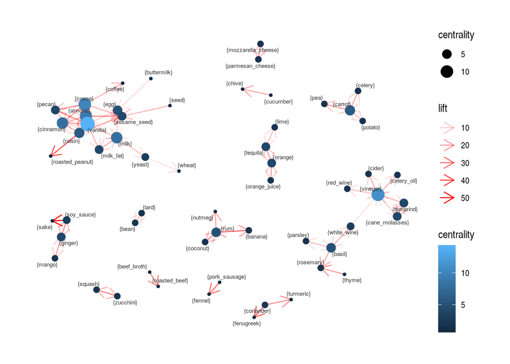

```r
# b_reglas_lift <- subset(b_reglas,
#                         hyper_lift > 1.75 & confidence > 0.1)

# Extraemos las reglas de tamaño 2.
reglas_f <- subset(b_reglas_lift, size(b_reglas_lift)==2)

# Se extrae un data frame y se cambian los nombres de LHS y RHS
df_reglas <- reglas_f %>% DATAFRAME %>% rename(from=LHS, to=RHS) %>% as_data_frame

# Se asigna un peso a cada canasta como el logaritmo del hyperlift
df_reglas$weight <- log(df_reglas$hyper_lift)

# Se hace un table_graph, donde pone la medida de centralidad de los objetos y las relaciones.
graph_1 <- as_tbl_graph(df_reglas) %>%
  mutate(centrality = centrality_degree(mode = "all"))

# Se obtiene la grafica de nodos.
ggraph(graph_1, layout = 'fr', start.temp=100) +
  geom_edge_link(aes(alpha=lift),
                 colour = 'red',
                 arrow = arrow(length = unit(4, 'mm'))) +
  geom_node_point(aes(size = centrality, colour = centrality)) +
  geom_node_text(aes(label = name), size=2,
                 colour = 'gray20', repel=TRUE) +
  theme_graph()
```

## Opción 2

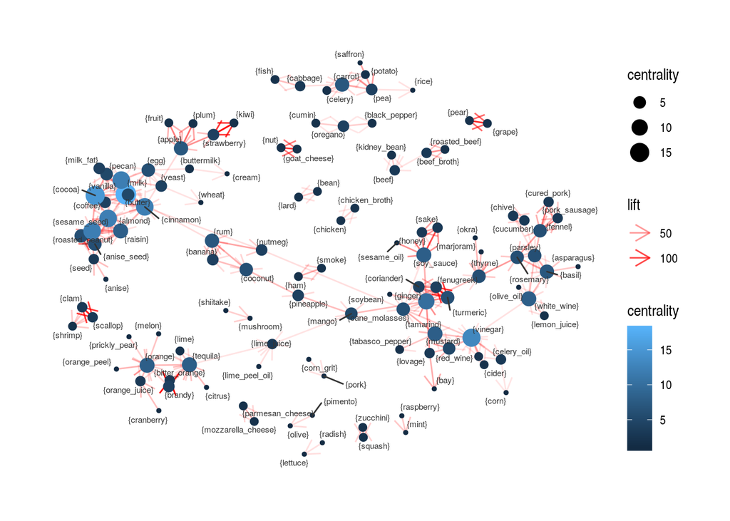

```r
b_reglas_lift <- subset(b_reglas,
                        hyper_lift > 2 & confidence > 0.1)

# Extraemos las reglas de tamaño 2.
reglas_f <- subset(b_reglas_lift, size(b_reglas_lift)==2)

# Se extrae un data frame y se cambian los nombres de LHS y RHS
df_reglas <- reglas_f %>% DATAFRAME %>% rename(from=LHS, to=RHS) %>% as_data_frame

# Se asigna un peso a cada canasta como el logaritmo del hyperlift
df_reglas$weight <- log(df_reglas$hyper_lift)

# Se hace un table_graph, donde pone la medida de centralidad de los objetos y las relaciones.
graph_1 <- as_tbl_graph(df_reglas) %>%
  mutate(centrality = centrality_degree(mode = "all"))

# Se obtiene la grafica de nodos.
ggraph(graph_1, layout = 'fr', start.temp=100) +
  geom_edge_link(aes(alpha=lift),
                 colour = 'red',
                 arrow = arrow(length = unit(4, 'mm'))) +
  geom_node_point(aes(size = centrality, colour = centrality)) +
  geom_node_text(aes(label = name), size=2,
                 colour = 'gray20', repel=TRUE) +
  theme_graph()
```

- Se tiene un grupo de carnes
- Se tiene un grupo de frutas
- Se tiene un grupo de arroz, zanahoria, papa, pescado
- Se tiene un grupo de pollo
- Se tiene un grupo de quesos
- Se tiene un grupo de calabazas
- Se tiene un grupo de jugos.
- Se tiene un grupo de alimentos para desayuno.